# Biostat 212a Homework 1

Due Jan 23, 2024 @ 11:59PM

Author

Yang An, UID: 106332601

Published

January 21, 2024

## 1 Filling gaps in lecture notes (10pts)

Consider the regression model
$$Y = f(X) + \epsilon,$$
where $\operatorname{E}(\epsilon) = 0$.

### 1.1 Optimal regression function

Show that the choice
$$f_{\text{opt}}(X) = \operatorname{E}(Y | X)$$
minimizes the mean squared prediction error
$$\operatorname{E}\{[Y - f(X)]^2\},$$
where the expectations averages over variations in both $X$ and $Y$. (Hint: condition on $X$.) **Answer**
$$\begin{aligned} \operatorname{E}\{[Y - f(X)]^2\} &= \operatorname{E}\{[Y - \operatorname{E}(Y | X) + \operatorname{E}(Y | X) - f(X)]^2\} \\ &= \operatorname{E}\{[Y - \operatorname{E}(Y | X)]^2\} + \operatorname{E}\{[\operatorname{E}(Y | X) - f(X)]^2\} \\ &= \operatorname{Var}(Y | X) + \operatorname{E}\{[\operatorname{E}(Y | X) - f(X)]^2\} \end{aligned}$$
Since$\operatorname{Var}(Y | X) \geq 0$, the minimum is achieved when $\operatorname{E}\{[\operatorname{E}(Y | X) - f(X)]^2\} = 0$, which is equivalent to $f(X) = \operatorname{E}(Y | X)$.

### 1.2 Bias-variance trade-off

Given an estimate $\hat f$ of $f$, show that the test error at a $x_0$ can be decomposed as
$$\operatorname{E}\{[y_0 - \hat f(x_0)]^2\} = \underbrace{\operatorname{Var}(\hat f(x_0)) + [\operatorname{Bias}(\hat f(x_0))]^2}_{\text{MSE of } \hat f(x_0) \text{ for estimating } f(x_0)} + \underbrace{\operatorname{Var}(\epsilon)}_{\text{irreducible}},$$
where the expectation averages over the variability in $y_0$ and $\hat f$. **Answer**
$$\begin{aligned} \operatorname{E}\{[y_0 - \hat f(x_0)]^2\} &= \operatorname{E}\{[y_0 - f(x_0) + f(x_0) - \hat f(x_0)]^2\} \\ &= \operatorname{E}\{[y_0 - f(x_0)]^2\} + \operatorname{E}\{[f(x_0) - \hat f(x_0)]^2\} \\ &= \operatorname{Var}(y_0) + \operatorname{E}\{[f(x_0) - \hat f(x_0)]^2\} \\ &= \operatorname{Var}(y_0) + \operatorname{Var}(\hat f(x_0)) + [\operatorname{Bias}(\hat f(x_0))]^2 \end{aligned}$$
where the last equality is due to the fact that
$$\operatorname{E}\{[f(x_0) - \hat f(x_0)]^2\} = \operatorname{Var}(\hat f(x_0)) + [\operatorname{Bias}(\hat f(x_0))]^2$$
.

## 2 ISL Exercise 2.4.3 (10pts)

**Answer** （a)

```r
library(tidyverse)
x <- seq(0.0, 10.0, 0.02)

squared_bias <- function(x) {
  return(0.002*(-x+10)^3)
}
variance <- function(x) {
  return(0.002*x^3)
}
training_error <- function(x) {
  return(2.38936 - 0.825077*x + 0.176655*x^2 - 0.0182319*x^3 + 0.00067091*x^4)
}
test_error <- function(x) {
  return(3 - 0.6*x + 0.06*x^2)
}
bayes_error <- function(x) {
  return(x + 1 - x)
}

plot(x, squared_bias(x), type='l', col='red', xlab='the amount of flexibility', ylab='values', ylim=c(0, 4), main='Bias-Variance Tradeoff')
lines(x, variance(x), col='blue')
lines(x, training_error(x), col='green')
lines(x, test_error(x), col='orange')
lines(x, bayes_error(x), col='purple')
legend('top', legend=c('Squared Bias', 'Variance', 'Training Error', 'Test Error', 'Bayes Error'), col=c('red', 'blue', 'green', 'orange', 'purple'), lty=1, cex=0.5)
```

[output not shown]

（b) 1. Bias: The bias curve typically decreases as the flexibility of the method increases. This is because more flexible methods can better fit the training data, reducing the bias. 2. Variance: The variance curve typically increases as the flexibility of the method increases. This is because more flexible methods are more prone to overfitting, leading to higher variance. 3. Training Error: The training error curve typically decreases as the flexibility of the method increases. This is because more flexible methods can better fit the training data, resulting in lower training error. 4. Test Error: The test error curve typically forms a U-shape, with a minimum point at an intermediate level of flexibility. This is because less flexible methods have high bias but low variance, leading to underfitting and high test error. More flexible methods have low bias but high variance, leading to overfitting and high test error. The optimal level of flexibility balances the bias and variance, resulting in the lowest test error. 5. Bayes Error: The Bayes (or irreducible) error curve is a horizontal line and represents the inherent error that cannot be reduced by any statistical learning method. It does not change with the flexibility of the method.

## 3 ISL Exercise 2.4.4 (10pts)

**Answer** (a) 1. Spam detection: The response is whether an email is spam or not. The predictors are the words in the email. The goal is prediction. 2. Credit card fraud detection: The response is whether a transaction is fraudulent or not. The predictors are the transaction amount, location, time, etc. The goal is prediction. 3. Medical diagnosis: The response is whether a patient has a certain disease or not. The predictors are the patient’s symptoms, test results, etc. The goal is inference. (b) 1. House price prediction: The response is the price of a house. The predictors are the house’s location, size, number of bedrooms, etc. The goal is prediction. 2. Stock price prediction: The response is the price of a stock. The predictors are the stock’s historical prices, trading volume, etc. The goal is prediction. 3. Weather forecasting: The response is the weather conditions. The predictors are the weather conditions in the past. The goal is prediction. (c) 1. Market segmentation: The goal is to divide customers into groups based on their purchasing behavior. 2. Social network analysis: The goal is to identify groups of people with similar interests. 3. Image segmentation: The goal is to identify objects in an image.

## 4 ISL Exercise 2.4.10 (30pts)

#### 4.0.1 R

**Answer**（a) There are 506 rows and 13 columns in this data set. Each row represents a census tract in Boston, and each column represents a predictor.

```r
library(tidyverse)

Boston <- read_csv("https://raw.githubusercontent.com/ucla-biostat-212a/2024winter/master/slides/data/Boston.csv", col_select = -1) %>%
  print(width = Inf)
```

```
# A tibble: 506 × 13
      crim    zn indus  chas   nox    rm   age   dis   rad   tax ptratio lstat
     <dbl> <dbl> <dbl> <dbl> <dbl> <dbl> <dbl> <dbl> <dbl> <dbl>   <dbl> <dbl>
 1 0.00632  18    2.31     0 0.538  6.58  65.2  4.09     1   296    15.3  4.98
 2 0.0273    0    7.07     0 0.469  6.42  78.9  4.97     2   242    17.8  9.14
 3 0.0273    0    7.07     0 0.469  7.18  61.1  4.97     2   242    17.8  4.03
 4 0.0324    0    2.18     0 0.458  7.00  45.8  6.06     3   222    18.7  2.94
 5 0.0690    0    2.18     0 0.458  7.15  54.2  6.06     3   222    18.7  5.33
 6 0.0298    0    2.18     0 0.458  6.43  58.7  6.06     3   222    18.7  5.21
 7 0.0883   12.5  7.87     0 0.524  6.01  66.6  5.56     5   311    15.2 12.4
 8 0.145    12.5  7.87     0 0.524  6.17  96.1  5.95     5   311    15.2 19.2
 9 0.211    12.5  7.87     0 0.524  5.63 100    6.08     5   311    15.2 29.9
10 0.170    12.5  7.87     0 0.524  6.00  85.9  6.59     5   311    15.2 17.1
    medv
   <dbl>
 1  24
 2  21.6
 3  34.7
 4  33.4
 5  36.2
 6  28.7
 7  22.9
 8  27.1
 9  16.5
10  18.9
# ℹ 496 more rows
```

#### 4.0.2 R

**Answer**（b) I explored some other scatterplots not shown below. In general, there aren’t many easily interpretable relationships between variables in this data set. Some pairs have clusters of data, but no overall trend; others have floor effects where most communities have a value of zero.

```r
ggscatter <- function(x, y) {
  ggplot(boston, aes({{ x }}, {{ y }})) +
    geom_point()
}

ggscatter(chas, crim) +
  labs(
    title = "Crime occurs more often away from the Charles River",
    subtitle = "Or, most suburbs are away from the Charles River"
  )
ggscatter(zn, nox) +
  labs(
    title = paste0(
      "Higher nitrogen oxide concentration in suburbs with all residential \n",
      "land zoning below 25,000 sq.ft.")
  )
ggscatter(ptratio, medv) +
  labs(
    title = paste0(
      "Higher pupil to teacher ratios are related to less \n",
      "valuable owner-occupied homes"
    )
  )
```

[output not shown]

#### 4.0.3 R

**Answer**(c) Yes, lower socioeconomic status and less valuable homes are associated with higher crime rates.

```r
ggscatter(crim, lstat) +
  labs(
    title = "Higher crime rates are associated with lower socioeconomic status"
  )
ggscatter(crim, medv) +
  labs(
    title = "Higher crime rates are associated with less valuable homes"
  )
```

[output not shown]

#### 4.0.4 R

```r
# draw histograms
attach(new_df)
par(mfrow=c(1,3))
hist(crim, breaks=10, col="2")
hist(tax, breaks=10, col="3")
hist(ptratio, breaks=10, col="4")
# Select only the variables
new_df <- select(Boston, crim, tax, ptratio)
# Calculate the range for each numerical column
range_num_vars <- lapply(new_df, range)
# Print the range for each numerical column
range_num_vars
```

[output not shown]

#### 4.0.5 R

**Answer**(e) There are 35 census tracts that bound the Charles River.

```r
boston %>%
  mutate(bound = if_else(chas == 1, "Yes", "No")) %>%
  group_by(bound) %>%
  summarise(
    n = n()
  )
```

[output not shown]

#### 4.0.6 R

**Answer**(f) The median pupil-teacher ratio is 19.05.

```r
boston %>%
  summarise(
    median_ptratio = median(ptratio)
  )
```

[output not shown]

#### 4.0.7 R

**Answer**（g) The census tract with the lowest median value of owner-occupied homes is 399. The values of the other predictors for that census tract are shown below. crim: above 3rd quartile, zn: at min indus: at 3rd quartile, chas: not bounded by river, nox: bove 3rd quartile, rm: below 1st quartile, age: at max, dis: below 1st quartile, rad: at max, tax: at 3rd quartile, ptratio: at 3rd quartile, lstat: above 3rd quartile, medv: at min.

```r
# the below will display the first record
lowest_record <- Boston[which.min(Boston$medv),]
print(lowest_record)
```

```
# A tibble: 1 × 13
   crim    zn indus  chas   nox    rm   age   dis   rad   tax ptratio lstat
  <dbl> <dbl> <dbl> <dbl> <dbl> <dbl> <dbl> <dbl> <dbl> <dbl>   <dbl> <dbl>
1  38.4     0  18.1     0 0.693  5.45   100  1.49    24   666    20.2  30.6
# ℹ 1 more variable: medv <dbl>
```

```r
# to display all the recods with the minimum value
t(subset(Boston, medv == min(medv)))
```

```
            [,1]     [,2]
crim     38.3518  67.9208
zn        0.0000   0.0000
indus    18.1000  18.1000
chas      0.0000   0.0000
nox       0.6930   0.6930
rm        5.4530   5.6830
age     100.0000 100.0000
dis       1.4896   1.4254
rad      24.0000  24.0000
tax     666.0000 666.0000
ptratio  20.2000  20.2000
lstat    30.5900  22.9800
medv      5.0000   5.0000
```

```r
summary(Boston)
```

```
      crim                zn             indus            chas
 Min.   : 0.00632   Min.   :  0.00   Min.   : 0.46   Min.   :0.00000
 1st Qu.: 0.08205   1st Qu.:  0.00   1st Qu.: 5.19   1st Qu.:0.00000
 Median : 0.25651   Median :  0.00   Median : 9.69   Median :0.00000
 Mean   : 3.61352   Mean   : 11.36   Mean   :11.14   Mean   :0.06917
 3rd Qu.: 3.67708   3rd Qu.: 12.50   3rd Qu.:18.10   3rd Qu.:0.00000
 Max.   :88.97620   Max.   :100.00   Max.   :27.74   Max.   :1.00000
      nox               rm             age              dis
 Min.   :0.3850   Min.   :3.561   Min.   :  2.90   Min.   : 1.130
 1st Qu.:0.4490   1st Qu.:5.886   1st Qu.: 45.02   1st Qu.: 2.100
 Median :0.5380   Median :6.208   Median : 77.50   Median : 3.207
 Mean   :0.5547   Mean   :6.285   Mean   : 68.57   Mean   : 3.795
 3rd Qu.:0.6240   3rd Qu.:6.623   3rd Qu.: 94.08   3rd Qu.: 5.188
 Max.   :0.8710   Max.   :8.780   Max.   :100.00   Max.   :12.127
      rad              tax           ptratio          lstat
 Min.   : 1.000   Min.   :187.0   Min.   :12.60   Min.   : 1.73
 1st Qu.: 4.000   1st Qu.:279.0   1st Qu.:17.40   1st Qu.: 6.95
 Median : 5.000   Median :330.0   Median :19.05   Median :11.36
 Mean   : 9.549   Mean   :408.2   Mean   :18.46   Mean   :12.65
 3rd Qu.:24.000   3rd Qu.:666.0   3rd Qu.:20.20   3rd Qu.:16.95
 Max.   :24.000   Max.   :711.0   Max.   :22.00   Max.   :37.97
      medv
 Min.   : 5.00
 1st Qu.:17.02
 Median :21.20
 Mean   :22.53
 3rd Qu.:25.00
 Max.   :50.00
```

#### 4.0.8 R

**Answer**(h) There are 64 census tracts that average more than seven rooms per dwelling, and 13 census tracts that average more than eight rooms per dwelling. The census tracts that average more than eight rooms per dwelling have a median value of owner-occupied homes that is higher than the overall median value of owner-occupied homes.

```r
boston %>%
  mutate(
    more_than_7_rooms = if_else(rm > 7, "Yes", "No"),
    more_than_8_rooms = if_else(rm > 8, "Yes", "No")
  ) %>%
  group_by(more_than_7_rooms, more_than_8_rooms) %>%
  summarise(
    n = n(),
    median_medv = median(medv),
    median_crim = median(crim)
  )
```

[output not shown]

## 5 ISL Exercise 3.7.3 (12pts)

**Answer** (a) iii is true. i:the equation to Salary = 50 + 20 * GPA + 0.07 * IQ + 35 * College + 0.01 * GPA * IQ - 10 * GPA * College We can estimate that High School graduates earn an average of 50 + 20* mean(GPA) + 0.07 * mean(IQ) + 0.01 * mean(GPA) * mean(IQ) and College graduates earn an average of 50 + 20 * mean(GPA) + 0.07 *mean(IQ) + 35 + 0.01 * mean(GPA) * mean(IQ) - 10 * mean(GPA). When you subtract out the common terms, you find out that College graduates earn an average of 35 - 10 * mean(GPA) more than High School graduates. Since we don’t know the value of mean(GPA), we don’t know whether High School graduates are outearning College graduates on average or not. ii:Again, this is indeterminate. iii:Since College are earning an of 35 - 10 * mean(GPA) more than men, a higher GPA mean means that College earn less than high school graduates, so this is true. iv:Since college are earning an average of 35 - 10 * mean(GPA) more than high school graduates, a higher GPA mean means that college earn less than high school graduates, so this is false.

**Answer** (b) 137.1 (50 + 20*4 + 0.07*110 + 35 + 0.01*4*110 - 10*4)=137.1

**Answer** (c) This is false, because the statistical significance of an interaction is different from the magnitude of the interaction. It’s possible to have a lot of evidence for a small effect. Also, a small coefficient doesn’t even mean the interaction effect is small, since it is very sensitive to the units of the two variables.

## 6 ISL Exercise 3.7.15 (20pts)

```r
#Loading the MASS package
library(MASS)
#reading the Boston Dataset
data("Boston")
attach(Boston)
#linear model crim ~ zn
linear_fit.zn <- lm(crim ~zn, data= Boston)
summary(linear_fit.zn)
```

```
Call:
lm(formula = crim ~ zn, data = Boston)

Residuals:
   Min     1Q Median     3Q    Max
-4.429 -4.222 -2.620  1.250 84.523

Coefficients:
            Estimate Std. Error t value Pr(>|t|)
(Intercept)  4.45369    0.41722  10.675  < 2e-16 ***
zn          -0.07393    0.01609  -4.594 5.51e-06 ***
---
Signif. codes:  0 '***' 0.001 '**' 0.01 '*' 0.05 '.' 0.1 ' ' 1

Residual standard error: 8.435 on 504 degrees of freedom
Multiple R-squared:  0.04019,   Adjusted R-squared:  0.03828
F-statistic:  21.1 on 1 and 504 DF,  p-value: 5.506e-06
```

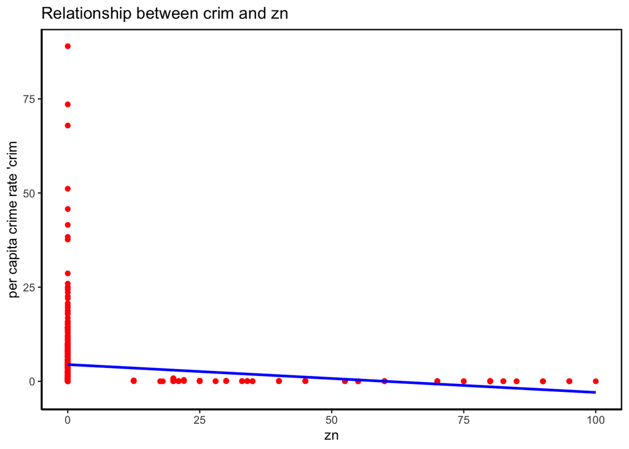

```r
#Ploting the model
ggplot(linear_fit.zn, aes(x = zn, y = crim)) +
  geom_point( color = "red") +
  geom_smooth(method = "lm", se = FALSE, color = "blue") +
  xlab("zn") +
  ylab("per capita crime rate 'crim") +
  ggtitle("Relationship between crim and zn") +
  theme_bw() +
  theme(panel.background = element_rect(colour = "black", linewidth = 1),
        panel.grid.major = element_blank(),
        panel.grid.minor = element_blank(),
        axis.line = element_line(colour = "black"))
```

The above graph confirms that there is a low negative relationship between the per capita crime rate and zn.

Per capita crime rate(crim) and Indus (proportion of non-retail business acres per town). There is a statistically significant relationship between the per capita and Indus. This is because the p-value of the model is 2e-16 which is far less than 0.05 The model can be described as: Y(crim)=β0 + β1(indus)X Y(crim)=−2.06374+0.50978x

```r
#linear model crim ~ indus
linear_fit.indus <- lm(crim ~ indus, data= Boston)
summary(linear_fit.indus)
```

```
Call:
lm(formula = crim ~ indus, data = Boston)

Residuals:
    Min      1Q  Median      3Q     Max
-11.972  -2.698  -0.736   0.712  81.813

Coefficients:
            Estimate Std. Error t value Pr(>|t|)
(Intercept) -2.06374    0.66723  -3.093  0.00209 **
indus        0.50978    0.05102   9.991  < 2e-16 ***
---
Signif. codes:  0 '***' 0.001 '**' 0.01 '*' 0.05 '.' 0.1 ' ' 1

Residual standard error: 7.866 on 504 degrees of freedom
Multiple R-squared:  0.1653,    Adjusted R-squared:  0.1637
F-statistic: 99.82 on 1 and 504 DF,  p-value: < 2.2e-16
```

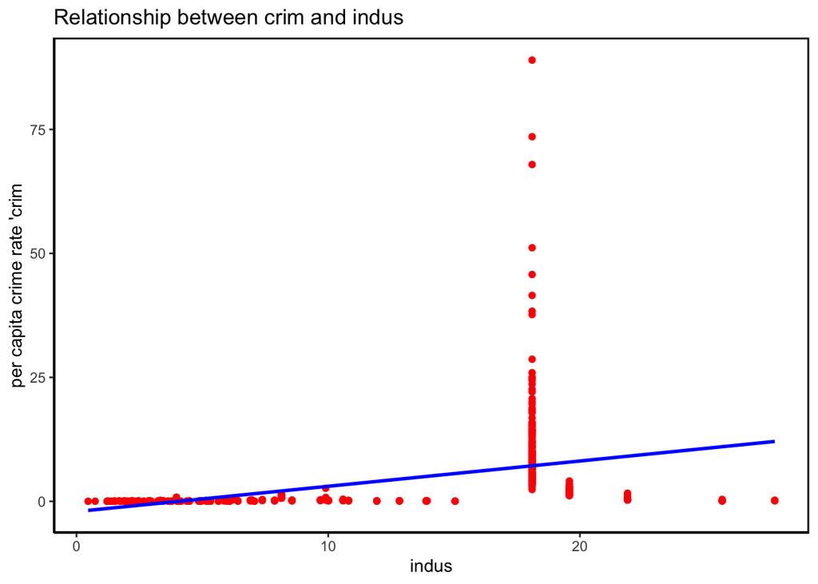

```r
#Ploting the model
ggplot(linear_fit.indus, aes(x = indus, y = crim)) +
  geom_point( color = "red") +
  geom_smooth(method = "lm", se = FALSE, color = "blue") +
  scale_x_continuous(breaks = seq(0, 30, by = 10)) +
  scale_y_continuous(breaks = seq(0, 90, by = 25)) +
  xlab("indus") +
  ylab("per capita crime rate 'crim") +
  ggtitle("Relationship between crim and indus") +
  theme_bw() +
  theme(panel.background = element_rect(colour = "black", linewidth = 1),
        panel.grid.major = element_blank(),
        panel.grid.minor = element_blank(),
        axis.line = element_line(colour = "black"))
```

The above graph confirms that there is a slightly positive relationship between the per capita crime rate and indus.

Per capita crime rate(crim) and chas (Charles River dummy variable (= 1 if tract bounds river; 0 otherwise)). The p-value of the model is 0.209 which is must great than 0.05 and this means that the chances of having a null hypothesis are high and therefore chas is not statistically significant. The R-squared value of 0.003124 and Adjusted R squared value of 0.001146 are extremely low which continues to confirm that there is no statistically significant association between per capita crime rate and chas. The model can be described as; Y(crim)=β0 + β1(chas)X Y(crim)=3.7444-1.8928x

```r
#linear model crim ~ chas
linear_fit.chas <- lm(crim ~ chas, data= Boston)
summary(linear_fit.chas)
```

```
Call:
lm(formula = crim ~ chas, data = Boston)

Residuals:
   Min     1Q Median     3Q    Max
-3.738 -3.661 -3.435  0.018 85.232

Coefficients:
            Estimate Std. Error t value Pr(>|t|)
(Intercept)   3.7444     0.3961   9.453   <2e-16 ***
chas         -1.8928     1.5061  -1.257    0.209
---
Signif. codes:  0 '***' 0.001 '**' 0.01 '*' 0.05 '.' 0.1 ' ' 1

Residual standard error: 8.597 on 504 degrees of freedom
Multiple R-squared:  0.003124,  Adjusted R-squared:  0.001146
F-statistic: 1.579 on 1 and 504 DF,  p-value: 0.2094
```

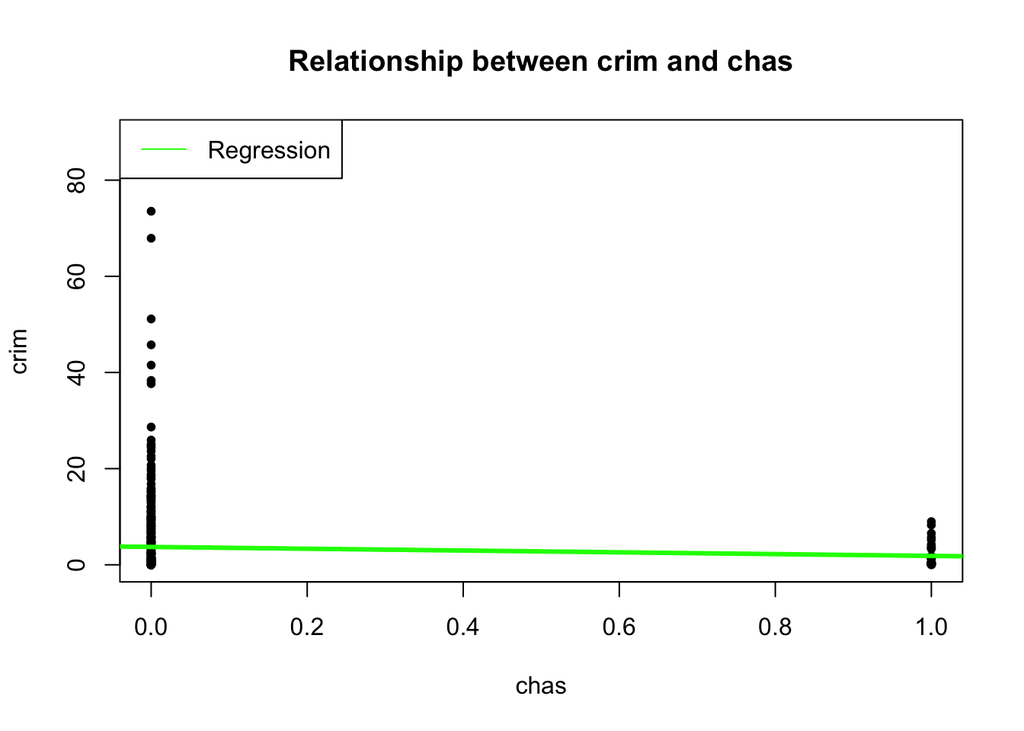

```r
#Ploting the model
plot(chas,crim,pch = 20, main = "Relationship between crim and chas")
abline(linear_fit.chas,col = "green",lwd = 3)
legend("topleft", c( "Regression"), col = c("green"), lty = c(1, 1))
```

The above graph illustrates that a change in chas is not accompanied by an increase in the per capita crime rate. And therefore we can conclude that there is no relationship between chas and the per capita crime rate.

Per capita crime rate(crim) and nox (nitric oxides concentration (parts per 10 million)). The 2e-16 p-value of the model is far less than 0.05 which makes the relationship between per capita crime rate and nitrogen oxide concentration statistically significant. Mathematically we can conclude that; Y(crim)=β0 + β1(nox)X Y(crim)=−13.7199+31.2490x

```r
#linear model crim ~ nox
linear_fit.nox <- lm(crim ~ nox, data= Boston)
summary(linear_fit.nox)
```

```
Call:
lm(formula = crim ~ nox, data = Boston)

Residuals:
    Min      1Q  Median      3Q     Max
-12.371  -2.738  -0.974   0.559  81.728

Coefficients:
            Estimate Std. Error t value Pr(>|t|)
(Intercept)  -13.720      1.699  -8.073 5.08e-15 ***
nox           31.249      2.999  10.419  < 2e-16 ***
---
Signif. codes:  0 '***' 0.001 '**' 0.01 '*' 0.05 '.' 0.1 ' ' 1

Residual standard error: 7.81 on 504 degrees of freedom
Multiple R-squared:  0.1772,    Adjusted R-squared:  0.1756
F-statistic: 108.6 on 1 and 504 DF,  p-value: < 2.2e-16
```

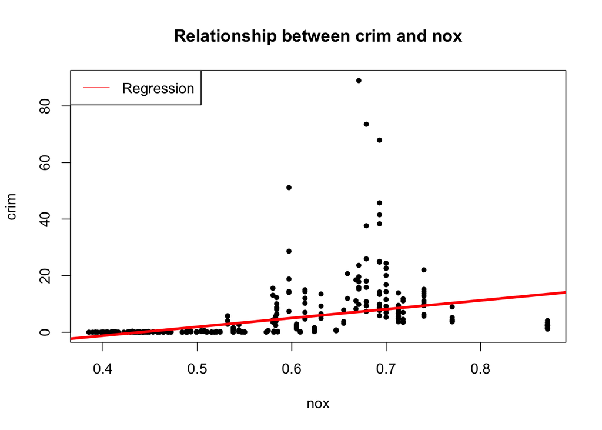

```r
##Ploting the model
plot(nox,crim,pch = 20, main = "Relationship between crim and nox")
abline(linear_fit.nox,col = "red",lwd = 3)
legend("topleft", c( "Regression"), col = c("red"), lty = c(1, 1))
```

The above graph illustrates that there is a a slightly lower positive relationship between the per capita crime rate and nitrogen oxide concentration. This low significant association is again confirmed by the low R squared value of 0.1772 and Adjusted R squared value of 0.1756.

Per capita crime rate(crim) and rm (average number of rooms per dwelling). There is a statistically significant association between the per capita crime rate and the average number of rooms per dwelling(rm) because of the p- of 6.35e-7 is smaller than 0.05. value. The model can be described as; Y(crim)=β0 + β1(rm)X Y(crim)=20.4818-2.6841x

```r
#linear model crim ~ rm
linear_fit.rm <- lm(crim ~ rm, data= Boston)
summary(linear_fit.rm)
```

```
Call:
lm(formula = crim ~ rm, data = Boston)

Residuals:
   Min     1Q Median     3Q    Max
-6.604 -3.952 -2.654  0.989 87.197

Coefficients:
            Estimate Std. Error t value Pr(>|t|)
(Intercept)   20.482      3.365   6.088 2.27e-09 ***
rm            -2.684      0.532  -5.045 6.35e-07 ***
---
Signif. codes:  0 '***' 0.001 '**' 0.01 '*' 0.05 '.' 0.1 ' ' 1

Residual standard error: 8.401 on 504 degrees of freedom
Multiple R-squared:  0.04807,   Adjusted R-squared:  0.04618
F-statistic: 25.45 on 1 and 504 DF,  p-value: 6.347e-07
```

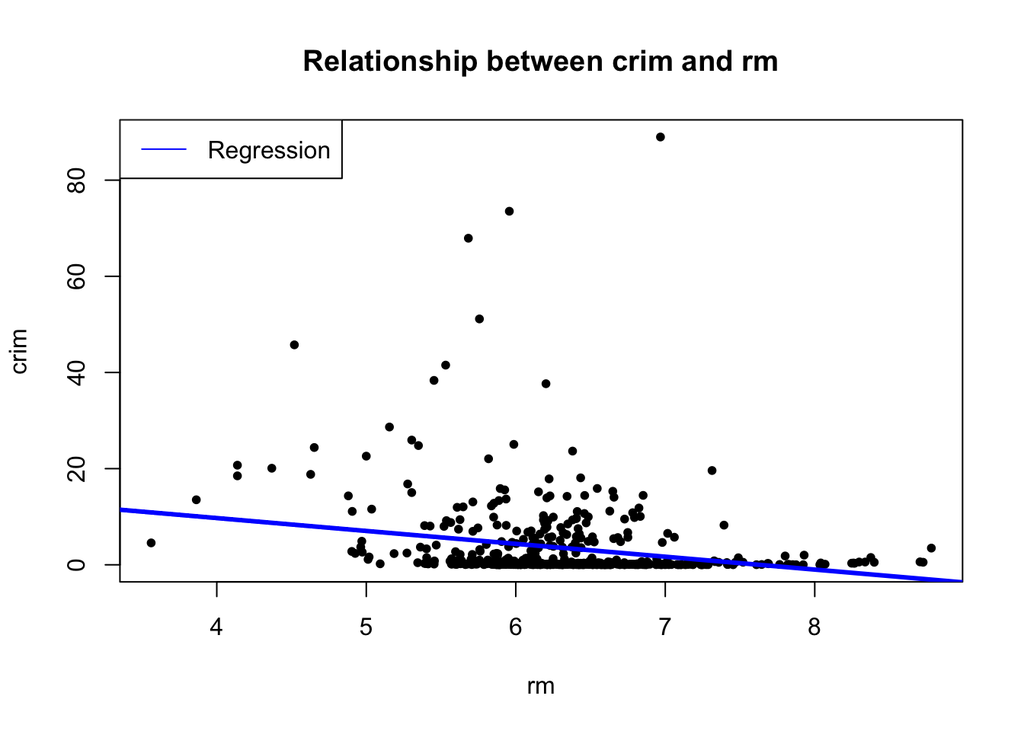

```r
#Ploting the model
plot(rm,crim,pch = 20, main = "Relationship between crim and rm")
abline(linear_fit.rm,col = "blue",lwd = 3)
legend("topleft", c( "Regression"), col = c("blue"), lty = c(1, 1))
```

Per capita crime rate(crim) and age (proportion of owner-occupied units built prior to 1940). The p-value of the model is 2.85e-16 which is far less than 0.05 and this means that there exists a statistically significant relationship between per capita crime and age. The model can be described as; Y(crim)=β0 + β1(age)X Y(crim)=−3.77791+0.10779x

```r
#linear model crim ~ age
linear_fit.age <- lm(crim ~ age, data= Boston)
summary(linear_fit.age)
```

```
Call:
lm(formula = crim ~ age, data = Boston)

Residuals:
   Min     1Q Median     3Q    Max
-6.789 -4.257 -1.230  1.527 82.849

Coefficients:
            Estimate Std. Error t value Pr(>|t|)
(Intercept) -3.77791    0.94398  -4.002 7.22e-05 ***
age          0.10779    0.01274   8.463 2.85e-16 ***
---
Signif. codes:  0 '***' 0.001 '**' 0.01 '*' 0.05 '.' 0.1 ' ' 1

Residual standard error: 8.057 on 504 degrees of freedom
Multiple R-squared:  0.1244,    Adjusted R-squared:  0.1227
F-statistic: 71.62 on 1 and 504 DF,  p-value: 2.855e-16
```

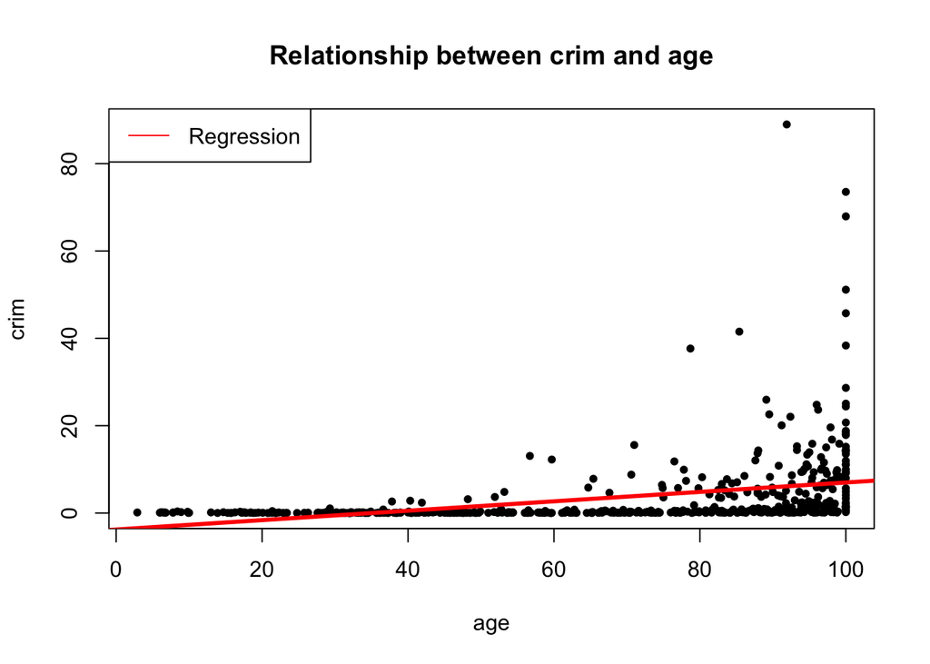

```r
#Ploting the model
plot(age,crim,pch = 20, main = "Relationship between crim and age")
abline(linear_fit.age,col = "red",lwd = 3)
legend("topleft", c( "Regression"), col = c("red"), lty = c(1, 1))
```

The above graph illustrates that there is a a slightly lower positive relationship between the per capita crime rate and the proportion of owner-occupied units built prior to 1940. This low significant association is again confirmed by the low R squared value of 0.1244 and Adjusted R squared value of 0.1227.

Per capita crime rate(crim) and dis (weighted mean of distances to five Boston employment centres). Because of the small p-value of 2e-16, there exists a statistically significant association between per capita crime rate and dis variable. Mathematically we can conclude that; Y(crim)=β0+ β1(dis)X Y(crim)=9.4993-1.5509x

```r
#linear model crim ~ dis
linear_fit.dis <- lm(crim ~ dis, data= Boston)
summary(linear_fit.dis)
```

```
Call:
lm(formula = crim ~ dis, data = Boston)

Residuals:
   Min     1Q Median     3Q    Max
-6.708 -4.134 -1.527  1.516 81.674

Coefficients:
            Estimate Std. Error t value Pr(>|t|)
(Intercept)   9.4993     0.7304  13.006   <2e-16 ***
dis          -1.5509     0.1683  -9.213   <2e-16 ***
---
Signif. codes:  0 '***' 0.001 '**' 0.01 '*' 0.05 '.' 0.1 ' ' 1

Residual standard error: 7.965 on 504 degrees of freedom
Multiple R-squared:  0.1441,    Adjusted R-squared:  0.1425
F-statistic: 84.89 on 1 and 504 DF,  p-value: < 2.2e-16
```

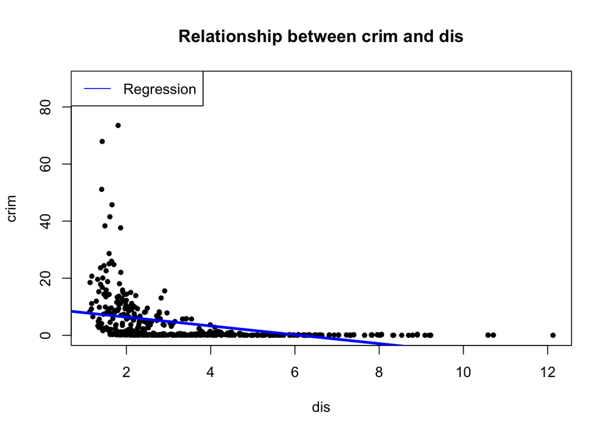

```r
#Ploting the model
plot(dis,crim,pch = 20, main = "Relationship between crim and dis")
abline(linear_fit.dis,col = "blue",lwd = 3)
legend("topleft", c( "Regression"), col = c("blue"), lty = c(1, 1))
```

The above graph illustrates that there is a a low sloping relationship between the per capita crime rate and the weighted mean of distances to five Boston employment centres. This low significant association is again confirmed by the low R squared value of 0.1441 and Adjusted R squared value of 0.1425.

Per capita crime rate(crim) and rad (index of accessibility to radial highways). The p-value of the model is 2.2e-16 which is far less than 0.05 and this means that there exists a statistically significant relationship between per capita crime and rad. The model can be described as; Y(crim)=β0 + β1(rad)X Y(crim)=−2.28716+0.61791x

```r
#linear model crim ~ rad
linear_fit.rad <- lm(crim ~ rad, data= Boston)
summary(linear_fit.rad)
```

```
Call:
lm(formula = crim ~ rad, data = Boston)

Residuals:
    Min      1Q  Median      3Q     Max
-10.164  -1.381  -0.141   0.660  76.433

Coefficients:
            Estimate Std. Error t value Pr(>|t|)
(Intercept) -2.28716    0.44348  -5.157 3.61e-07 ***
rad          0.61791    0.03433  17.998  < 2e-16 ***
---
Signif. codes:  0 '***' 0.001 '**' 0.01 '*' 0.05 '.' 0.1 ' ' 1

Residual standard error: 6.718 on 504 degrees of freedom
Multiple R-squared:  0.3913,    Adjusted R-squared:   0.39
F-statistic: 323.9 on 1 and 504 DF,  p-value: < 2.2e-16
```

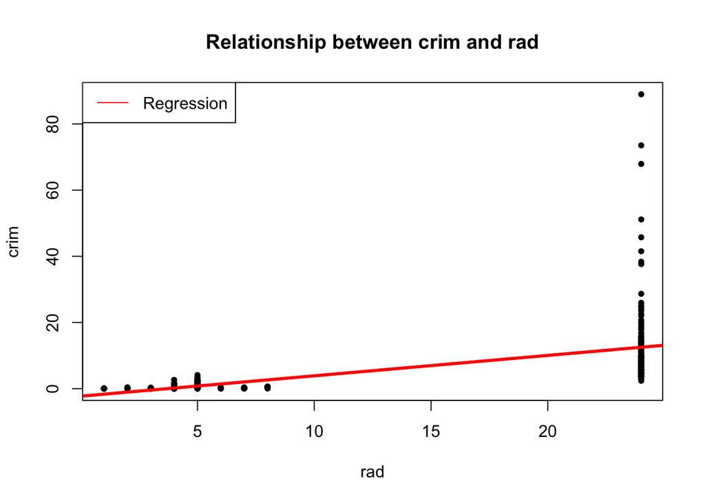

```r
#Ploting the model
plot(rad,crim,pch = 20, main = "Relationship between crim and rad")
abline(linear_fit.rad,col = "red",lwd = 3)
legend("topleft", c( "Regression"), col = c("red"), lty = c(1, 1))
```

The above graph illustrates that there is a a slightly lower positive relationship between the per capita crime rate and the index of accessibility to radial highways. This low significant association is again confirmed by the low R squared value of 0.3913 and Adjusted R squared value of 0.3899.

Per capita crime rate(crim) and tax (full-value property-tax rate per $10,000). The p-value of the model is 2.2e-16 which is far less than 0.05 and this means that there exists a statistically significant relationship between per capita crime and tax. The model can be described as: Y(crim)=β0 + β1(tax)X Y(crim)=−8.52837+0.02974x

```r
#linear model crim ~ tax
linear_fit.tax <- lm(crim ~ tax, data= Boston)
summary(linear_fit.tax)
```

```
Call:
lm(formula = crim ~ tax, data = Boston)

Residuals:
    Min      1Q  Median      3Q     Max
-12.513  -2.738  -0.194   1.065  77.696

Coefficients:
             Estimate Std. Error t value Pr(>|t|)
(Intercept) -8.528369   0.815809  -10.45   <2e-16 ***
tax          0.029742   0.001847   16.10   <2e-16 ***
---
Signif. codes:  0 '***' 0.001 '**' 0.01 '*' 0.05 '.' 0.1 ' ' 1

Residual standard error: 6.997 on 504 degrees of freedom
Multiple R-squared:  0.3396,    Adjusted R-squared:  0.3383
F-statistic: 259.2 on 1 and 504 DF,  p-value: < 2.2e-16
```

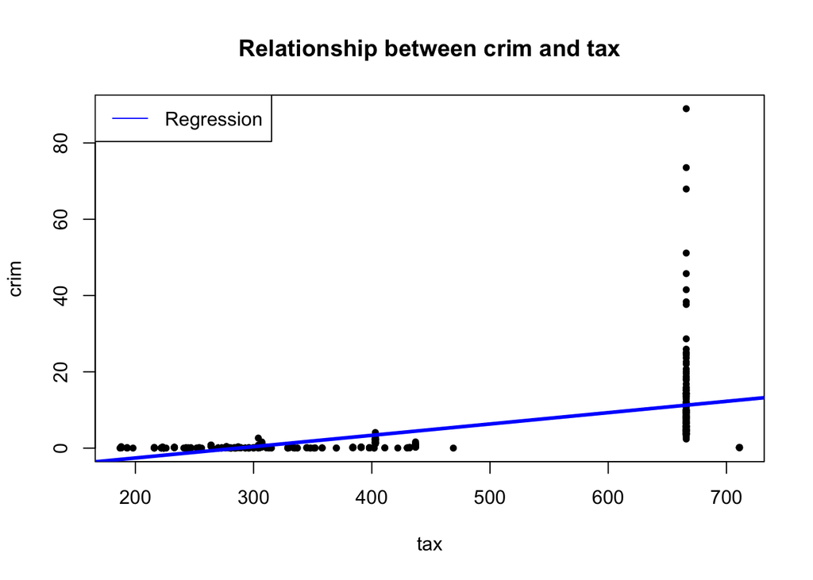

```r
#Ploting the model
plot(tax,crim,pch = 20, main = "Relationship between crim and tax")
abline(linear_fit.tax,col = "blue",lwd = 3)
legend("topleft", c( "Regression"), col = c("blue"), lty = c(1, 1))
```

Per capita crime rate(crim) and black. The p-value of the model is 2.2e-16 which is far less than 0.05 and this means that there exists a statistically significant relationship between per capita crime and black. The model can be described as: Y(crim)=β0 + β1(black)X Y(crim)=16.55353-0.03628x

```r
#linear model crim ~ black
linear_fit.black <- lm(crim ~ black, data= Boston)
summary(linear_fit.black)
```

```
Call:
lm(formula = crim ~ black, data = Boston)

Residuals:
    Min      1Q  Median      3Q     Max
-13.756  -2.299  -2.095  -1.296  86.822

Coefficients:
             Estimate Std. Error t value Pr(>|t|)
(Intercept) 16.553529   1.425903  11.609   <2e-16 ***
black       -0.036280   0.003873  -9.367   <2e-16 ***
---
Signif. codes:  0 '***' 0.001 '**' 0.01 '*' 0.05 '.' 0.1 ' ' 1

Residual standard error: 7.946 on 504 degrees of freedom
Multiple R-squared:  0.1483,    Adjusted R-squared:  0.1466
F-statistic: 87.74 on 1 and 504 DF,  p-value: < 2.2e-16
```

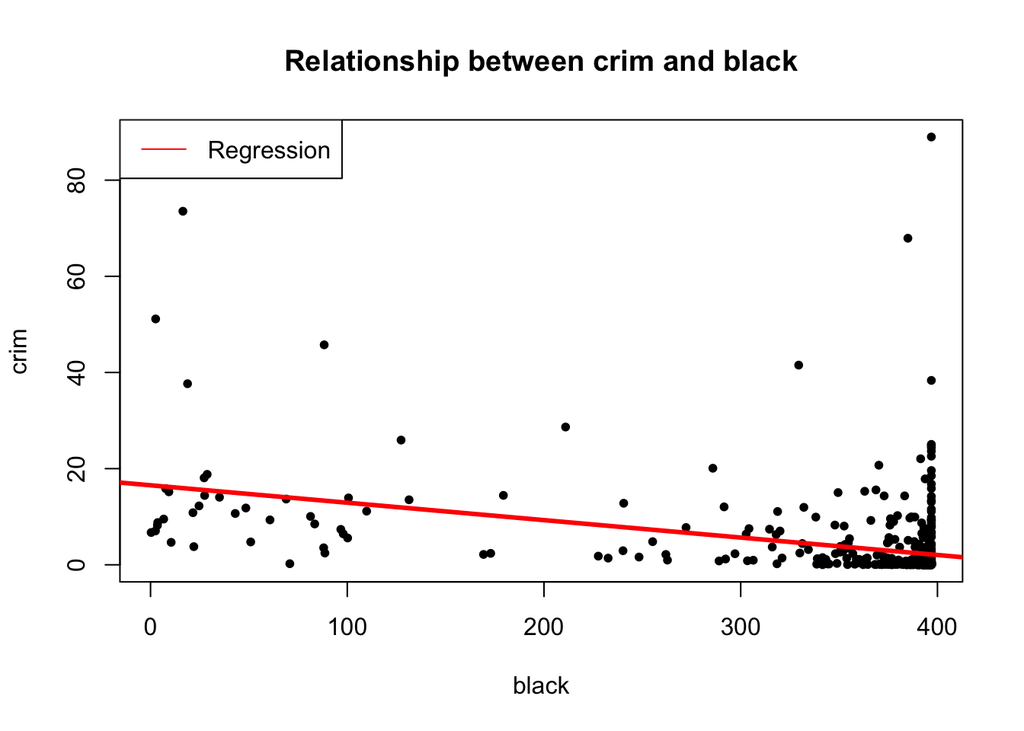

```r
#Ploting the model
plot(black,crim,pch = 20, main = "Relationship between crim and black")
abline(linear_fit.black,col = "red",lwd = 3)
legend("topleft", c( "Regression"), col = c("red"), lty = c(1, 1))
```

The above graph illustrates that there is a a slightly negative relationship between the per capita crime rate and the black. This low significant association is again confirmed by the low R squared value of 0.1483 and Adjusted R squared value of 0.1466.

```r
#linear model crim ~ ptratio
linear_fit.ptratio <- lm(crim ~ ptratio, data= Boston)
summary(linear_fit.ptratio)
```

```
Call:
lm(formula = crim ~ ptratio, data = Boston)

Residuals:
   Min     1Q Median     3Q    Max
-7.654 -3.985 -1.912  1.825 83.353

Coefficients:
            Estimate Std. Error t value Pr(>|t|)
(Intercept) -17.6469     3.1473  -5.607 3.40e-08 ***
ptratio       1.1520     0.1694   6.801 2.94e-11 ***
---
Signif. codes:  0 '***' 0.001 '**' 0.01 '*' 0.05 '.' 0.1 ' ' 1

Residual standard error: 8.24 on 504 degrees of freedom
Multiple R-squared:  0.08407,   Adjusted R-squared:  0.08225
F-statistic: 46.26 on 1 and 504 DF,  p-value: 2.943e-11
```

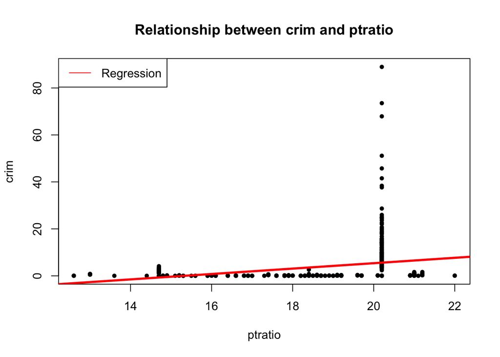

```r
#Ploting the model
plot(ptratio,crim,pch = 20, main = "Relationship between crim and ptratio")
abline(linear_fit.ptratio,col = "red",lwd = 3)
legend("topleft", c( "Regression"), col = c("red"), lty = c(1, 1))
```

Per capita crime rate(crim) and lstat (lower status of the population (percent)). The p-value of 2e-16 is way below the 0.05 and therefore we can conclude that there is a statistically significant association between the per capita crime rate and lstat. Mathematically we can conclude that; Y(crim)=β0 + β_1 (lstat)X Y(crim)=-3.33054+0.54880x

```r
#linear model crim ~ lstat
linear_fit.lstat <- lm(crim ~ lstat, data= Boston)
summary(linear_fit.lstat)
```

```
Call:
lm(formula = crim ~ lstat, data = Boston)

Residuals:
    Min      1Q  Median      3Q     Max
-13.925  -2.822  -0.664   1.079  82.862

Coefficients:
            Estimate Std. Error t value Pr(>|t|)
(Intercept) -3.33054    0.69376  -4.801 2.09e-06 ***
lstat        0.54880    0.04776  11.491  < 2e-16 ***
---
Signif. codes:  0 '***' 0.001 '**' 0.01 '*' 0.05 '.' 0.1 ' ' 1

Residual standard error: 7.664 on 504 degrees of freedom
Multiple R-squared:  0.2076,    Adjusted R-squared:  0.206
F-statistic:   132 on 1 and 504 DF,  p-value: < 2.2e-16
```

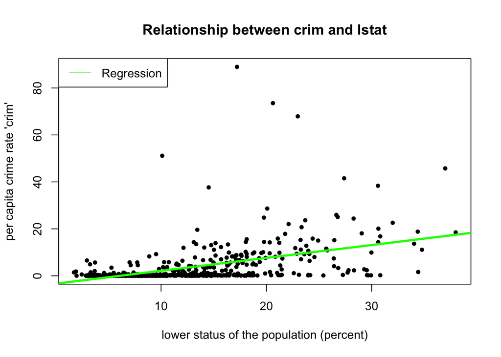

```r
#Ploting the model
plot(lstat,crim,pch = 20, main = "Relationship between crim and lstat",
     ylab = "per capita crime rate 'crim'", xlab = "lower status of the population (percent)")
abline(linear_fit.lstat,col = "green",lwd = 3)
legend("topleft", c( "Regression"), col = c("green"), lty = c(1, 1))
```

Per capita crime rate(crim) and medv (median value of owner-occupied homes in $1000s). There is a statistically significant association between the per capita crime rate and medv because of the small p-value of 2e-16. Mathematically we can conclude that; Y(crim)=β0 + β_1 (medv)X Y(crim)=11.79654-0.36316x

```r
#linear model crim ~ medv
linear_fit.medv <- lm(crim ~ medv, data= Boston)
summary(linear_fit.medv)
```

```
Call:
lm(formula = crim ~ medv, data = Boston)

Residuals:
   Min     1Q Median     3Q    Max
-9.071 -4.022 -2.343  1.298 80.957

Coefficients:
            Estimate Std. Error t value Pr(>|t|)
(Intercept) 11.79654    0.93419   12.63   <2e-16 ***
medv        -0.36316    0.03839   -9.46   <2e-16 ***
---
Signif. codes:  0 '***' 0.001 '**' 0.01 '*' 0.05 '.' 0.1 ' ' 1

Residual standard error: 7.934 on 504 degrees of freedom
Multiple R-squared:  0.1508,    Adjusted R-squared:  0.1491
F-statistic: 89.49 on 1 and 504 DF,  p-value: < 2.2e-16
```

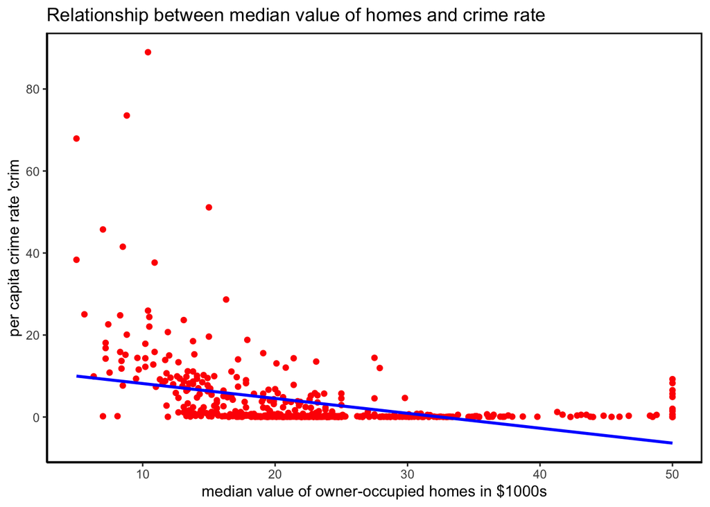

```r
#Ploting the model
ggplot(linear_fit.medv, aes(x = medv, y = crim)) +
  geom_point( color = "red") +
  geom_smooth(method = "lm", se = FALSE, color = "blue") +
  scale_x_continuous(breaks = seq(0, 50, by = 10)) +
  scale_y_continuous(breaks = seq(0, 80, by = 20)) +
  xlab("median value of owner-occupied homes in $1000s") +
  ylab("per capita crime rate 'crim") +
  ggtitle("Relationship between median value of homes and crime rate") +
  theme_bw() +
  theme(panel.background = element_rect(colour = "black", linewidth = 1),
        panel.grid.major = element_blank(),
        panel.grid.minor = element_blank(),
        axis.line = element_line(colour = "black"))
```

The graph above illustrates and confirms the statistically significant negative relationship between the per capita crime rate and medv. The association is quite small due to a low R squared value of 0.1508 and Adjusted R squared value of 0.1491.

**Answer**(b)

```r
#Multiple linear regression
multi_fit <- lm(crim ~ ., data= Boston)
summary(multi_fit)
```

```
Call:
lm(formula = crim ~ ., data = Boston)

Residuals:
   Min     1Q Median     3Q    Max
-9.924 -2.120 -0.353  1.019 75.051

Coefficients:
              Estimate Std. Error t value Pr(>|t|)
(Intercept)  17.033228   7.234903   2.354 0.018949 *
zn            0.044855   0.018734   2.394 0.017025 *
indus        -0.063855   0.083407  -0.766 0.444294
chas         -0.749134   1.180147  -0.635 0.525867
nox         -10.313535   5.275536  -1.955 0.051152 .
rm            0.430131   0.612830   0.702 0.483089
age           0.001452   0.017925   0.081 0.935488
dis          -0.987176   0.281817  -3.503 0.000502 ***
rad           0.588209   0.088049   6.680 6.46e-11 ***
tax          -0.003780   0.005156  -0.733 0.463793
ptratio      -0.271081   0.186450  -1.454 0.146611
black        -0.007538   0.003673  -2.052 0.040702 *
lstat         0.126211   0.075725   1.667 0.096208 .
medv         -0.198887   0.060516  -3.287 0.001087 **
---
Signif. codes:  0 '***' 0.001 '**' 0.01 '*' 0.05 '.' 0.1 ' ' 1

Residual standard error: 6.439 on 492 degrees of freedom
Multiple R-squared:  0.454, Adjusted R-squared:  0.4396
F-statistic: 31.47 on 13 and 492 DF,  p-value: < 2.2e-16
```

```r
# Better summary table
library(gtsummary)
multi_fit %>%
  tbl_regression() %>%
  bold_labels() %>%
  bold_p(t = 0.05) %>%
  modify_column_unhide(columns = c(statistic, std.error)) %>%
  add_glance_source_note(
    label = list(sigma ~ "\U03C3"),
    include = c(r.squared, sigma)
  )
```

| **Characteristic** | **Beta** | **SE**<sup>1</sup> | **Statistic** | **95% CI**<sup>1</sup> | **p-value** |
| --- | --- | --- | --- | --- | --- |
| zn | 0.04 | 0.019 | 2.39 | 0.01, 0.08 | 0.017 |
| indus | -0.06 | 0.083 | -0.766 | -0.23, 0.10 | 0.4 |
| chas | -0.75 | 1.18 | -0.635 | -3.1, 1.6 | 0.5 |
| nox | -10 | 5.28 | -1.95 | -21, 0.05 | 0.051 |
| rm | 0.43 | 0.613 | 0.702 | -0.77, 1.6 | 0.5 |
| age | 0.00 | 0.018 | 0.081 | -0.03, 0.04 | >0.9 |
| dis | -0.99 | 0.282 | -3.50 | -1.5, -0.43 | <0.001 |
| rad | 0.59 | 0.088 | 6.68 | 0.42, 0.76 | <0.001 |
| tax | 0.00 | 0.005 | -0.733 | -0.01, 0.01 | 0.5 |
| ptratio | -0.27 | 0.186 | -1.45 | -0.64, 0.10 | 0.15 |
| black | -0.01 | 0.004 | -2.05 | -0.01, 0.00 | 0.041 |
| lstat | 0.13 | 0.076 | 1.67 | -0.02, 0.27 | 0.10 |
| medv | -0.20 | 0.061 | -3.29 | -0.32, -0.08 | 0.001 |

R² = 0.454; σ = 6.44  
<sup>1</sup> SE = Standard Error, CI = Confidence Interval

The above model shows that the predictors zn, dis, rad, black and medv are statistically significant because their p-values are less than 0.05. Other remaining variables because of their high p-values, we cannot reject the null hypothesis (H0: βj= 0).In conclusion, we can only reject the null hypothesis for “zn”, ”dis”, ”rad”, ”black” and “medv”. The multiple regression model generally does not fit the Boston dataset very well because of the low R squared value of 0.454 and the Adjusted R squared value of 0.4396

**Answer**(c)

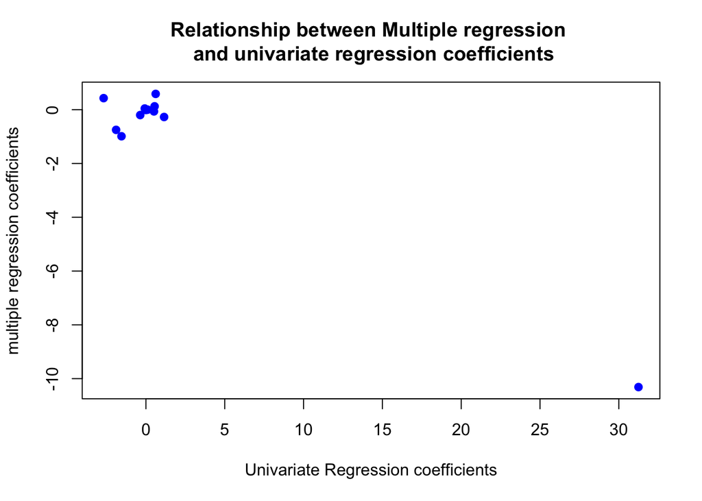

```r
#Plotting a scatter plot of Multiple regression Vs Univariate regression coefficients
univeriate_reg <- vector("numeric",0)
univeriate_reg <- c(univeriate_reg, linear_fit.zn$coefficient[2])
univeriate_reg <- c(univeriate_reg, linear_fit.indus$coefficient[2])
univeriate_reg <- c(univeriate_reg, linear_fit.chas$coefficient[2])
univeriate_reg <- c(univeriate_reg, linear_fit.nox$coefficient[2])
univeriate_reg <- c(univeriate_reg, linear_fit.rm$coefficient[2])
univeriate_reg <- c(univeriate_reg, linear_fit.age$coefficient[2])
univeriate_reg <- c(univeriate_reg, linear_fit.dis$coefficient[2])
univeriate_reg <- c(univeriate_reg, linear_fit.rad$coefficient[2])
univeriate_reg <- c(univeriate_reg, linear_fit.tax$coefficient[2])
univeriate_reg <- c(univeriate_reg, linear_fit.ptratio$coefficient[2])
univeriate_reg <- c(univeriate_reg, linear_fit.black$coefficient[2])
univeriate_reg <- c(univeriate_reg, linear_fit.lstat$coefficient[2])
univeriate_reg <- c(univeriate_reg, linear_fit.medv$coefficient[2])
multiple_reg <- vector("numeric", 0)
multiple_reg <- c(multiple_reg, multi_fit$coefficients)
multiple_reg <- multiple_reg[-1]
plot(univeriate_reg, multiple_reg, col = "blue",pch =19, ylab = "multiple regression coefficients",
     xlab = "Univariate Regression coefficients",
     main = "Relationship between Multiple regression \n and univariate regression coefficients")
```

Univariate and multiple regression coefficients have a distinct difference. This is because the slope of the simple regression model represents the average effect of an increase in the predictor ignoring the other predictors in the dataset. But multiple regression holds other predictors fixed, and its slope represents the average effect of an increase in the predictor.

We have seen in the above-fitted models that multiple regression suggests no relationship between per capita crime rate and most of the predictors while for the simple regression it’s vice versa and this because there is some strong correlation between some predictors as shown in the correlation table below.

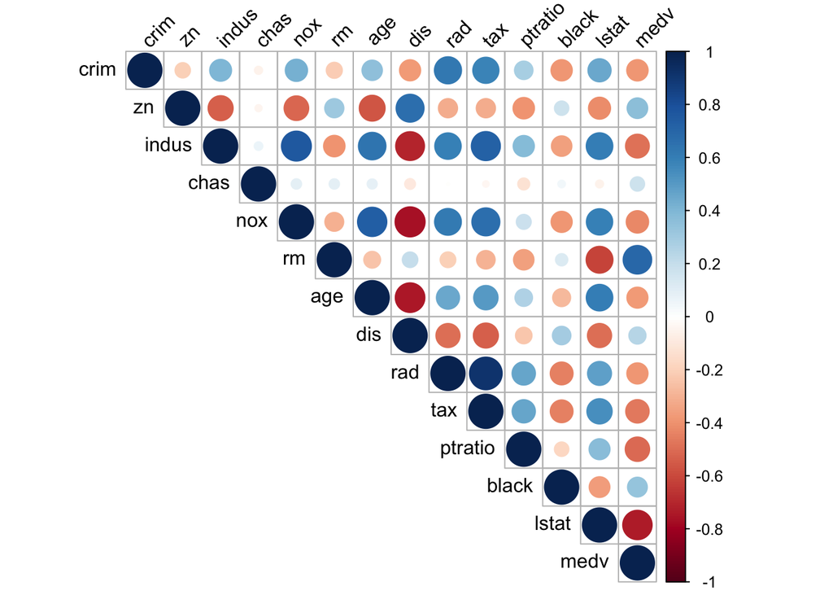

```r
#Correlation table
library(corrplot)
correlation <- cor(Boston)
corrplot(correlation, method = "circle", type = "upper", tl.col = "black", tl.srt = 45)
```

**Answer**(d)

```r
poly_zn <- lm(crim ~ poly(zn, 3), data = Boston)
summary(poly_zn)
```

```
Call:
lm(formula = crim ~ poly(zn, 3), data = Boston)

Residuals:
   Min     1Q Median     3Q    Max
-4.821 -4.614 -1.294  0.473 84.130

Coefficients:
             Estimate Std. Error t value Pr(>|t|)
(Intercept)    3.6135     0.3722   9.709  < 2e-16 ***
poly(zn, 3)1 -38.7498     8.3722  -4.628  4.7e-06 ***
poly(zn, 3)2  23.9398     8.3722   2.859  0.00442 **
poly(zn, 3)3 -10.0719     8.3722  -1.203  0.22954
---
Signif. codes:  0 '***' 0.001 '**' 0.01 '*' 0.05 '.' 0.1 ' ' 1

Residual standard error: 8.372 on 502 degrees of freedom
Multiple R-squared:  0.05824,   Adjusted R-squared:  0.05261
F-statistic: 10.35 on 3 and 502 DF,  p-value: 1.281e-06
```

```r
poly_indus <- lm(crim ~ poly(indus, 3), data = Boston)
summary(poly_indus)
```

```
Call:
lm(formula = crim ~ poly(indus, 3), data = Boston)

Residuals:
   Min     1Q Median     3Q    Max
-8.278 -2.514  0.054  0.764 79.713

Coefficients:
                Estimate Std. Error t value Pr(>|t|)
(Intercept)        3.614      0.330  10.950  < 2e-16 ***
poly(indus, 3)1   78.591      7.423  10.587  < 2e-16 ***
poly(indus, 3)2  -24.395      7.423  -3.286  0.00109 **
poly(indus, 3)3  -54.130      7.423  -7.292  1.2e-12 ***
---
Signif. codes:  0 '***' 0.001 '**' 0.01 '*' 0.05 '.' 0.1 ' ' 1

Residual standard error: 7.423 on 502 degrees of freedom
Multiple R-squared:  0.2597,    Adjusted R-squared:  0.2552
F-statistic: 58.69 on 3 and 502 DF,  p-value: < 2.2e-16
```

```r
poly_nox <- lm(crim ~ poly(nox, 3), data = Boston)
summary(poly_nox)
```

```
Call:
lm(formula = crim ~ poly(nox, 3), data = Boston)

Residuals:
   Min     1Q Median     3Q    Max
-9.110 -2.068 -0.255  0.739 78.302

Coefficients:
              Estimate Std. Error t value Pr(>|t|)
(Intercept)     3.6135     0.3216  11.237  < 2e-16 ***
poly(nox, 3)1  81.3720     7.2336  11.249  < 2e-16 ***
poly(nox, 3)2 -28.8286     7.2336  -3.985 7.74e-05 ***
poly(nox, 3)3 -60.3619     7.2336  -8.345 6.96e-16 ***
---
Signif. codes:  0 '***' 0.001 '**' 0.01 '*' 0.05 '.' 0.1 ' ' 1

Residual standard error: 7.234 on 502 degrees of freedom
Multiple R-squared:  0.297, Adjusted R-squared:  0.2928
F-statistic: 70.69 on 3 and 502 DF,  p-value: < 2.2e-16
```

```r
poly_age <- lm(crim ~ poly(age, 3), data = Boston)
summary(poly_age)
```

```
Call:
lm(formula = crim ~ poly(age, 3), data = Boston)

Residuals:
   Min     1Q Median     3Q    Max
-9.762 -2.673 -0.516  0.019 82.842

Coefficients:
              Estimate Std. Error t value Pr(>|t|)
(Intercept)     3.6135     0.3485  10.368  < 2e-16 ***
poly(age, 3)1  68.1820     7.8397   8.697  < 2e-16 ***
poly(age, 3)2  37.4845     7.8397   4.781 2.29e-06 ***
poly(age, 3)3  21.3532     7.8397   2.724  0.00668 **
---
Signif. codes:  0 '***' 0.001 '**' 0.01 '*' 0.05 '.' 0.1 ' ' 1

Residual standard error: 7.84 on 502 degrees of freedom
Multiple R-squared:  0.1742,    Adjusted R-squared:  0.1693
F-statistic: 35.31 on 3 and 502 DF,  p-value: < 2.2e-16
```

```r
poly_dis <- lm(crim ~ poly(dis, 3), data = Boston)
summary(poly_dis)
```

```
Call:
lm(formula = crim ~ poly(dis, 3), data = Boston)

Residuals:
    Min      1Q  Median      3Q     Max
-10.757  -2.588   0.031   1.267  76.378

Coefficients:
              Estimate Std. Error t value Pr(>|t|)
(Intercept)     3.6135     0.3259  11.087  < 2e-16 ***
poly(dis, 3)1 -73.3886     7.3315 -10.010  < 2e-16 ***
poly(dis, 3)2  56.3730     7.3315   7.689 7.87e-14 ***
poly(dis, 3)3 -42.6219     7.3315  -5.814 1.09e-08 ***
---
Signif. codes:  0 '***' 0.001 '**' 0.01 '*' 0.05 '.' 0.1 ' ' 1

Residual standard error: 7.331 on 502 degrees of freedom
Multiple R-squared:  0.2778,    Adjusted R-squared:  0.2735
F-statistic: 64.37 on 3 and 502 DF,  p-value: < 2.2e-16
```

```r
poly_rad <- lm(crim ~ poly(rad, 3), data = Boston)
summary(poly_rad)
```

```
Call:
lm(formula = crim ~ poly(rad, 3), data = Boston)

Residuals:
    Min      1Q  Median      3Q     Max
-10.381  -0.412  -0.269   0.179  76.217

Coefficients:
              Estimate Std. Error t value Pr(>|t|)
(Intercept)     3.6135     0.2971  12.164  < 2e-16 ***
poly(rad, 3)1 120.9074     6.6824  18.093  < 2e-16 ***
poly(rad, 3)2  17.4923     6.6824   2.618  0.00912 **
poly(rad, 3)3   4.6985     6.6824   0.703  0.48231
---
Signif. codes:  0 '***' 0.001 '**' 0.01 '*' 0.05 '.' 0.1 ' ' 1

Residual standard error: 6.682 on 502 degrees of freedom
Multiple R-squared:    0.4, Adjusted R-squared:  0.3965
F-statistic: 111.6 on 3 and 502 DF,  p-value: < 2.2e-16
```

```r
poly_tax <- lm(crim ~ poly(tax, 3), data = Boston)
summary(poly_tax)
```

```
Call:
lm(formula = crim ~ poly(tax, 3), data = Boston)

Residuals:
    Min      1Q  Median      3Q     Max
-13.273  -1.389   0.046   0.536  76.950

Coefficients:
              Estimate Std. Error t value Pr(>|t|)
(Intercept)     3.6135     0.3047  11.860  < 2e-16 ***
poly(tax, 3)1 112.6458     6.8537  16.436  < 2e-16 ***
poly(tax, 3)2  32.0873     6.8537   4.682 3.67e-06 ***
poly(tax, 3)3  -7.9968     6.8537  -1.167    0.244
---
Signif. codes:  0 '***' 0.001 '**' 0.01 '*' 0.05 '.' 0.1 ' ' 1

Residual standard error: 6.854 on 502 degrees of freedom
Multiple R-squared:  0.3689,    Adjusted R-squared:  0.3651
F-statistic:  97.8 on 3 and 502 DF,  p-value: < 2.2e-16
```

```r
poly_ptratio <- lm(crim ~ poly(ptratio, 3), data = Boston)
summary(poly_ptratio)
```

```
Call:
lm(formula = crim ~ poly(ptratio, 3), data = Boston)

Residuals:
   Min     1Q Median     3Q    Max
-6.833 -4.146 -1.655  1.408 82.697

Coefficients:
                  Estimate Std. Error t value Pr(>|t|)
(Intercept)          3.614      0.361  10.008  < 2e-16 ***
poly(ptratio, 3)1   56.045      8.122   6.901 1.57e-11 ***
poly(ptratio, 3)2   24.775      8.122   3.050  0.00241 **
poly(ptratio, 3)3  -22.280      8.122  -2.743  0.00630 **
---
Signif. codes:  0 '***' 0.001 '**' 0.01 '*' 0.05 '.' 0.1 ' ' 1

Residual standard error: 8.122 on 502 degrees of freedom
Multiple R-squared:  0.1138,    Adjusted R-squared:  0.1085
F-statistic: 21.48 on 3 and 502 DF,  p-value: 4.171e-13
```

```r
poly_black <- lm(crim ~ poly(black, 3), data = Boston)
summary(poly_black)
```

```
Call:
lm(formula = crim ~ poly(black, 3), data = Boston)

Residuals:
    Min      1Q  Median      3Q     Max
-13.096  -2.343  -2.128  -1.439  86.790

Coefficients:
                Estimate Std. Error t value Pr(>|t|)
(Intercept)       3.6135     0.3536  10.218   <2e-16 ***
poly(black, 3)1 -74.4312     7.9546  -9.357   <2e-16 ***
poly(black, 3)2   5.9264     7.9546   0.745    0.457
poly(black, 3)3  -4.8346     7.9546  -0.608    0.544
---
Signif. codes:  0 '***' 0.001 '**' 0.01 '*' 0.05 '.' 0.1 ' ' 1

Residual standard error: 7.955 on 502 degrees of freedom
Multiple R-squared:  0.1498,    Adjusted R-squared:  0.1448
F-statistic: 29.49 on 3 and 502 DF,  p-value: < 2.2e-16
```

```r
poly_lstat <- lm(crim ~ poly(lstat, 3), data = Boston)
summary(poly_lstat)
```

```
Call:
lm(formula = crim ~ poly(lstat, 3), data = Boston)

Residuals:
    Min      1Q  Median      3Q     Max
-15.234  -2.151  -0.486   0.066  83.353

Coefficients:
                Estimate Std. Error t value Pr(>|t|)
(Intercept)       3.6135     0.3392  10.654   <2e-16 ***
poly(lstat, 3)1  88.0697     7.6294  11.543   <2e-16 ***
poly(lstat, 3)2  15.8882     7.6294   2.082   0.0378 *
poly(lstat, 3)3 -11.5740     7.6294  -1.517   0.1299
---
Signif. codes:  0 '***' 0.001 '**' 0.01 '*' 0.05 '.' 0.1 ' ' 1

Residual standard error: 7.629 on 502 degrees of freedom
Multiple R-squared:  0.2179,    Adjusted R-squared:  0.2133
F-statistic: 46.63 on 3 and 502 DF,  p-value: < 2.2e-16
```

```r
poly_medv <- lm(crim ~ poly(medv, 3), data = Boston)
summary(poly_medv)
```

```
Call:
lm(formula = crim ~ poly(medv, 3), data = Boston)

Residuals:
    Min      1Q  Median      3Q     Max
-24.427  -1.976  -0.437   0.439  73.655

Coefficients:
               Estimate Std. Error t value Pr(>|t|)
(Intercept)       3.614      0.292  12.374  < 2e-16 ***
poly(medv, 3)1  -75.058      6.569 -11.426  < 2e-16 ***
poly(medv, 3)2   88.086      6.569  13.409  < 2e-16 ***
poly(medv, 3)3  -48.033      6.569  -7.312 1.05e-12 ***
---
Signif. codes:  0 '***' 0.001 '**' 0.01 '*' 0.05 '.' 0.1 ' ' 1

Residual standard error: 6.569 on 502 degrees of freedom
Multiple R-squared:  0.4202,    Adjusted R-squared:  0.4167
F-statistic: 121.3 on 3 and 502 DF,  p-value: < 2.2e-16
```

```r
poly_rm <- lm(crim ~ poly(rm, 3), data = Boston)
summary(poly_rm)
```

```
Call:
lm(formula = crim ~ poly(rm, 3), data = Boston)

Residuals:
    Min      1Q  Median      3Q     Max
-18.485  -3.468  -2.221  -0.015  87.219

Coefficients:
             Estimate Std. Error t value Pr(>|t|)
(Intercept)    3.6135     0.3703   9.758  < 2e-16 ***
poly(rm, 3)1 -42.3794     8.3297  -5.088 5.13e-07 ***
poly(rm, 3)2  26.5768     8.3297   3.191  0.00151 **
poly(rm, 3)3  -5.5103     8.3297  -0.662  0.50858
---
Signif. codes:  0 '***' 0.001 '**' 0.01 '*' 0.05 '.' 0.1 ' ' 1

Residual standard error: 8.33 on 502 degrees of freedom
Multiple R-squared:  0.06779,   Adjusted R-squared:  0.06222
F-statistic: 12.17 on 3 and 502 DF,  p-value: 1.067e-07
```

From the above summary tables, we can see that the p-values for the indus, nox, age, dis, ptratio, medv are less than 0.05. This means that we can reject the null hypothesis (H0: βj= 0) and conclude that there is a non-linear association between the per capita crime rate and these predictors.

## 7 Bonus question (20pts)

**Answer**

$$R^2 = 1 - \frac{\text{RSS}}{\text{TSS}}$$
$$\text{RSS} = \sum_{i=1}^{n} (y_i - \hat{y_i})^2$$
$$\text{TSS} = \sum_{i=1}^{n} (y_i - \bar{y})^2$$
$$\text{RSS} = \sum_{i=1}^{n} (y_i - \hat{y_i})^2 = (\mathbf{y} - \hat{\mathbf{y}})^T (\mathbf{y} - \hat{\mathbf{y}})$$
$$\text{TSS} = \sum_{i=1}^{n} (y_i - \bar{y})^2 = (\mathbf{y} - \bar{\mathbf{y}})^T (\mathbf{y} - \bar{\mathbf{y}})$$

```r
#Loading the Boston dataset
library(MASS)
data(Boston)
#Fitting the multiple regression model
multi_fit <- lm(crim ~ ., data = Boston)
#Calculating the R squared value
r.squared <- summary(multi_fit)$r.squared
#Calculating the correlation between the response vector and the fitted values
correlation <- cor(Boston$crim, multi_fit$fitted.values)
#Calculating the square of the correlation
correlation.squared <- correlation^2
#Comparing the two values
r.squared
```

```
[1] 0.4540104
```

```r
correlation.squared
```

```
[1] 0.4540104
```